[figure not shown]

# Business informational systems and business management

**Business informational systems**  
**Assoc. prof. Darko Etinger, Ph.D.**

## Enterprise as a business system

The business system is **adaptive** because it has the ability to detect changes and adapt to new conditions.

Information about changes observed at the output of the system by the **feedback mechanism is** sent back to the input. This allows the operation of the system to be regulated.

Management processes have the role of **a control** or **management mechanism** .

## Organization and business information systems (1/2)

- the organization’s business encompasses a range of **business events**
- the business event generates **data** (eg invoice, bank payment slip, exam application form, ()
- data is used to **record, confirm and control the execution of business** (events)
- data are processed into **information** (eg list of 10 largest customers, list of students who passed Informatics, ()
- without data it would be difficult to do business (execute business processes), and without information it would be difficult to manage business

## Organization and business information systems (2/2)

**Material, data, management and information flows** enter and exit the organization

1. material flows - **executive subsystem** : data
2. control flows - **control subsystem** : information
3. data and information flows - **information subsystem** : records, processes and presents data and information, allows the business system to communicate (connecting executive and management subsystem ) and provides connection organisations with the environment

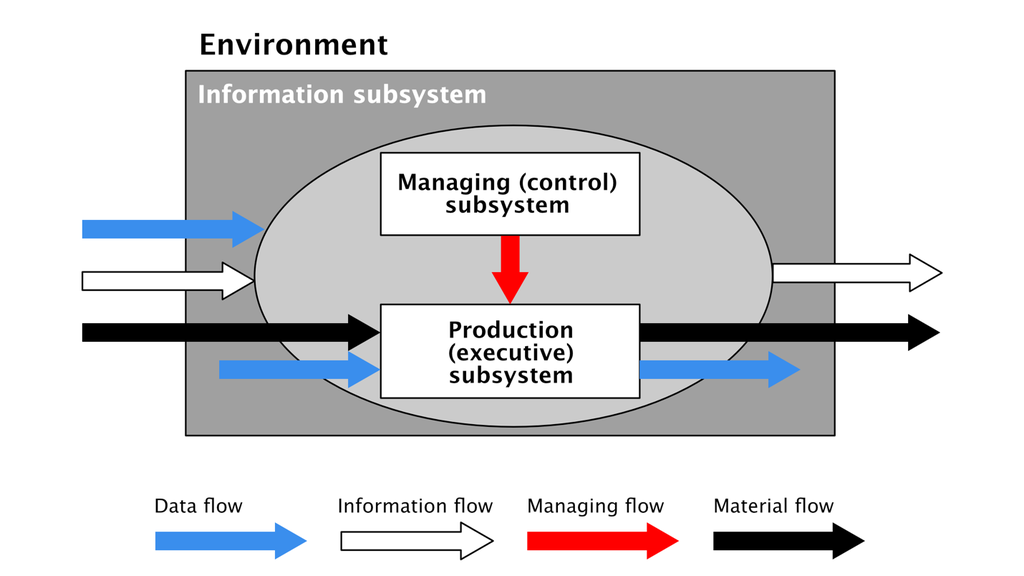

The business information system should provide support for:

- **executive subsystem** for performing business process - **transaction processing system**
- **management system management subsystem** - management **support system**
- **communication subsystem** for achieving cooperation and communication within the business system and towards the environment - **system for communication and cooperation**

## Executive subsystem

- serves to perform business processes
- the business process describes the tasks performed within the organization
- through the implementation of business processes, business activity takes place:
  - production company - the business process consists of the procurement of necessary raw materials and energy, production, placement of manufactured products, etc .;
  - bank - business process includes transactions of financial transactions of payments and disbursements, lending, savings, etc.
- IT can increase the efficiency of business process execution (automate, make more efficient ()

## Management subsystem

- to manage means to decide, plan, control and organize
- the basis of management is decision-making - information is needed for successful decision-making
- information is obtained by processing data from various sources
  - data generated in the business process (internal data) - eg data on the type and number of manufactured products (
  - data generated outside the business system (external data) - eg data on the state of the market, the state of stock exchanges (
  - data generated in the decision-making process (data created by managers) - eg production plans, sales plan (
- structured, poorly structured and unstructured decision making - different information needs
- operational, tactical, strategic management - different information needs

## Communication subsystem

- performs communication and collaborative activities:
  - between the executive and management subsystem and
  - between the business system and its environment (clients, business partners, state administration, ()
- preparation and exchange of documents, presentations, reports, etc.

## Transaction Processing System

- provides support for the ongoing business process - transaction processing
- monitoring of routine business events (monitoring and processing of orders, invoicing, inventory tracking, inventory calculation, personnel records, etc.)

General functions: - keeping records - recording records of each transaction in the database - issuing - generating various documents required in business - reporting - monitoring the business process

## Management Support System (1/3)

- early 80's - Management Information Systems (MIS)
  - "Produces" routine (programmed) and pre-specified reports, solves simple queries, intended for the operational level of management (management reporting system or reporting information system)
- Decision Support Systems (DSS)
  - “Upgraded” MIS which, in addition to the database and modern processing techniques and procedures, also receives models (methods) of decision-making and a user interface for the realization of user-system dialogue
  - oriented to specific, poorly structured decision-making situations and higher levels of management

## Management Support System (2/3)

- early 90's - a new generation of decision support systems - data warehousing and business intelligence systems (BI systems)
  - support for a number of different decision-making situations and levels of governance
  - the role of the system is to provide the user with sufficient relevant information, and to provide him with various procedures for quality analysis of available data
  - helps to find the cause of a phenomenon
  - users create a variety of analytical data processing and discover knowledge without the need for classical programming
  - software solutions for large and complex data processing: analytical processing (OLAP) and in-depth data analysis (Data Mining - DM)
  - OLAP and DM tools (software) allow you to get answers to increasingly complex business questions

## Management Support System (3/3)

- new generation of BI systems - business performance management systems, business performance management systems (corporate performance) (BPM) system, Corporate Performance Management system, etc.)
  - support and other management activities: planning, control and organization
  - performance management - planning of all business segments, creation and monitoring of key business indicators, which show how the organization really operates, and analysis of the causes and sources of deviations between the plan and results
  - upgrading the BI system with specialized analytical applications for financial and operational planning, financial management, forecasting, management of key business indicators, modeling applications, applications for monitoring a balanced map of effects / goals, etc.

## Communication system _ and cooperation

- collaborative system
- once: an office business system
- communication - telephone, fax, e-mail, intranet
- support for cooperation (group work) - group decision-making and communication (decision-making room, teleconferences)
- support for individual work - better efficiency (MS Office)
- content management (documents) document search - databases, Web

## Functional view of PIS modules

PISG support to individual business areas - PISG modules:

- **module of finance and accounting** - financial planning and monitoring of company capital, general ledger, processing of incoming and outgoing invoices, processing of orders, purchasing and warehousing operations and processing of salaries
- **sales and marketing module** - data on products (which products or services to offer?), on price (at what price?), on promotion (which promotion strategy to apply?) and on sales method (which distribution channels to apply?)
- **human resources module** - provides data and information to identify potential new employees, provides all the necessary data on existing employees and designs programs to develop knowledge and skills of employees.
- **production module** - inventory management and company logistics, production planning, product development, computer-aided production management (CAD, CAM CIM), procurement process management

# Integrated Business Information System (1/3)

- software solutions for building an integrated PIS which eliminates the shortcomings of unrelated applications
- Emergence of the 1990s - Enterprise Resource Planning (ERP)
- synonymous with standard business application software
- software architecture based on a common database and user interface ensures a smooth flow of information between parts of the organization and provides a comprehensive information view of the business system

# Integrated business information system (2/3)

- "Old ERP" is being upgraded with concepts such as BI, EPM (Enterprise Performance Management) and BPM (Business Performance Management).
- more developed "new" ERP - provides integral support to management, communication and cooperation - the so-called. Enterprise Resource Management (ERM) system
- connecting PISG business partners to achieve efficiency in the entire value chain (upgrade with CRM, SCM and SRM systems) - open ERP or ERP II

> by connecting ERM and ERP II we are talking about a complete integrated business information system (IPIS)

# Integrated business information system (3/3)

- organization and processes integrated
- provides a shift in the orientation of the organization from subordination to functional parts to the creation of efficiency of the organization as a whole through support for strategic goals and key business processes
- includes and connects the transaction processing system, management support system, communication and cooperation system, as well as modules of individual business areas, data of business areas and organizational levels are well connected, and functional and process connectivity within the organization is easily achieved. with the environment
- it is possible to effectively manage and decide on individual areas and levels, as well as at the level of the system as a whole

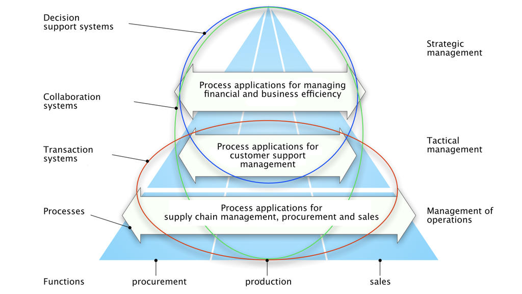

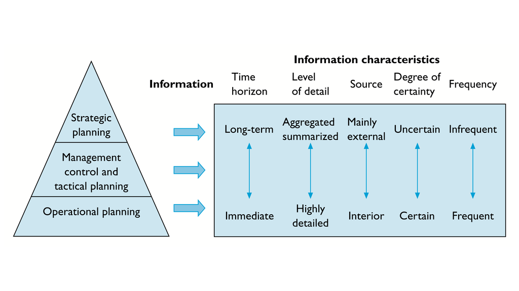

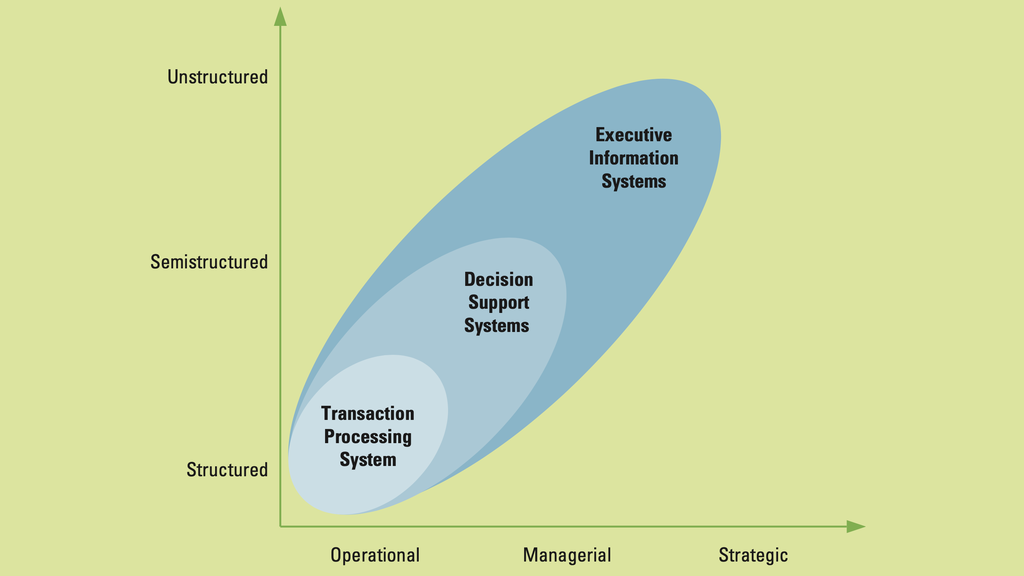

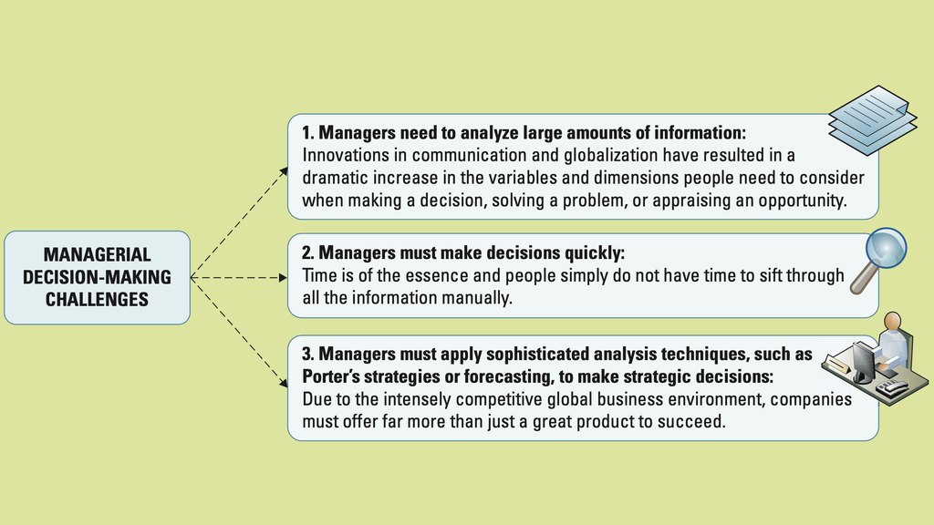

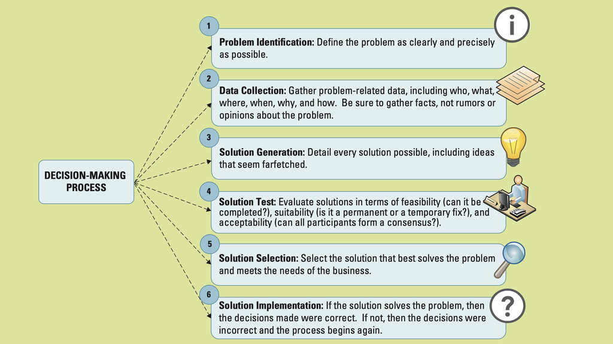

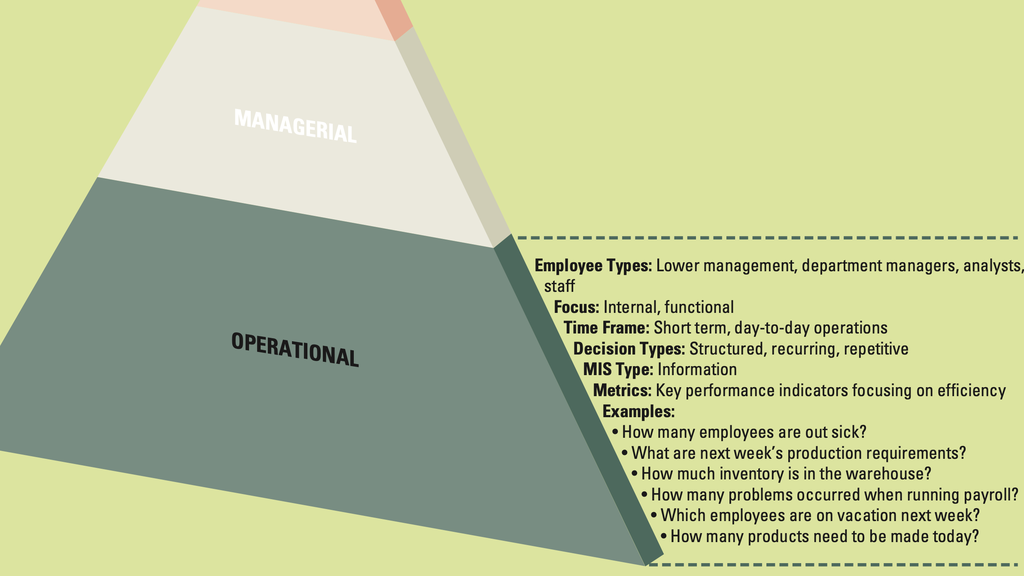

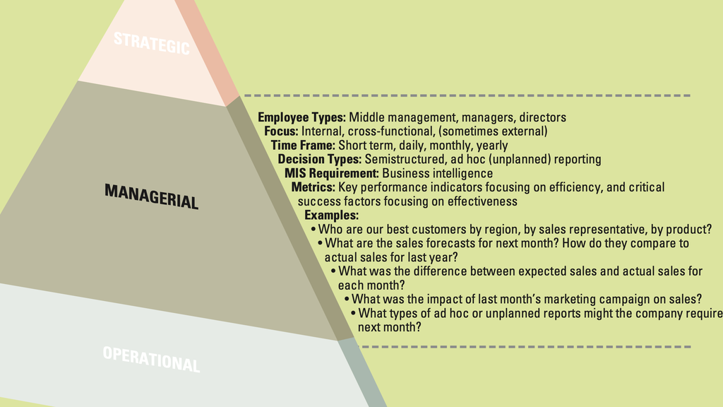

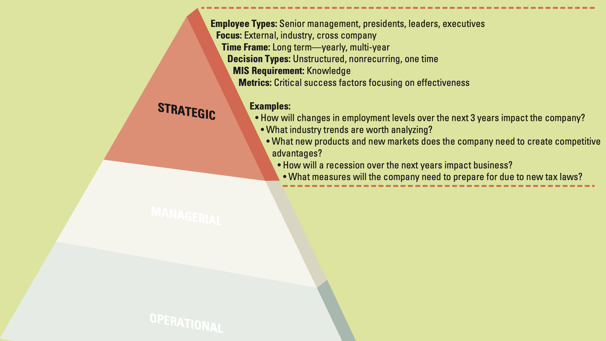